# Model-Performance-Linear

Rich McGowan

April 24, 2018

#### The purpose of this analysis is to perform and assess a Multiple Linear Regression model for predicting Total Course Enrollment.

#### The first step is to initialize the project: After the project has been created in the target directory make sure the ProjectTemplate package is installed and loaded. The COURSE_CAPACITY_DATA.csv and TOTAL_ENRL_ATTEMPTS_BY_COURSE.csv files have been moved into the Data folder of the project template and will be loaded into the environment. This will also load all necessary packages (designated in/by the Config file of the project).

#### The COURSE_CAPACITY_DATA.csv file and the TOTAL_ENRL_ATTEMPTS_BY_COURSE file.csv contain approximately 13K rows of course schedule statisics for terms between Fall of 2016 and the Spring of 2018. The data frame is intended to facilitate the prediction of ultimate Enrollment Totals per scheduled course (for all primary/enrollmment scheduled sections).

```r
course_capacity_local <- tbl_df(COURSE.CAPACITY.DATA)
total_enrl_attempts_local <- tbl_df(TOTAL.ENRL.ATTEMPTS.BY.COURSE)
```

#### Combine the appropriate columns in the 2 data frames (i.e. add the TotalAttempts column from total_enrl_attempts_local to course_capacity_local matching on CourseID and Term).

```r
combined_data_local <- merge(course_capacity_local, total_enrl_attempts_local, by= c('CourseID','Term'))
```

#### Filter all pre Spring 2018 rows from the combined_data_local dataframe to isolate a (Fall 2016 - Fall 2017 only) training dataset. Filter all Spring 2018 rows from the combined_data_local dataframe to isolate a (Spring 2018 only) dataset.

```r
training_data_local <- combined_data_local %>% filter(Term < 2182)
test_data_local <- combined_data_local %>% filter(Term >= 2182)
```

#### Exclude columns of the training_data_local and test_data_local datasets to minimized them so they only include variables of interest to the model. The resulting training_data_minimzed dataset will then be used for some graphical exploratory analysis using the “pairs” function.

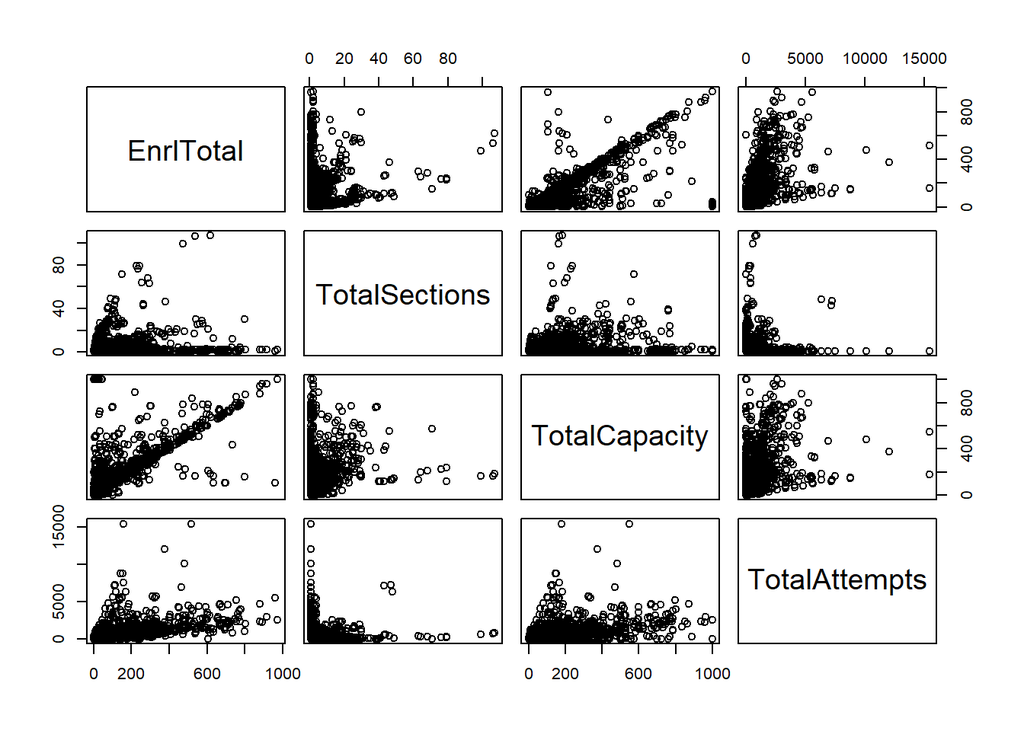

```r
training_data_minimized <- training_data_local %>% select(EnrlTotal, TotalSections, TotalCapacity,TotalAttempts)
test_data_minimized <- test_data_local %>% select(EnrlTotal, TotalSections, TotalCapacity,TotalAttempts)
pairs(training_data_minimized)
```

#### Use the “cor” function to show a correlation matrix for further exploratory analysis.

```r
cor(training_data_minimized)
```

```
##               EnrlTotal TotalSections TotalCapacity TotalAttempts
## EnrlTotal     1.0000000    0.22514619     0.7542981    0.64294347
## TotalSections 0.2251462    1.00000000     0.2729550    0.08585135
## TotalCapacity 0.7542981    0.27295497     1.0000000    0.46787930
## TotalAttempts 0.6429435    0.08585135     0.4678793    1.00000000
```

#### Create a Multiple Linear Regression Model to explain the relationship between Response Variable (EnrlTotal-from the training_data_local dataset) and several explanatory variables from the traning_data_local dataset.

```r
fit <- lm(EnrlTotal ~ TotalSections + TotalCapacity + TotalAttempts, data = training_data_minimized)
summary(fit)
```

```
##
## Call:
## lm(formula = EnrlTotal ~ TotalSections + TotalCapacity + TotalAttempts,
##     data = training_data_minimized)
##
## Residuals:
##     Min      1Q  Median      3Q     Max
## -750.97   -8.42   -2.53    6.37  642.19
##
## Coefficients:
##                Estimate Std. Error t value Pr(>|t|)
## (Intercept)   4.4568860  0.6007977   7.418 1.29e-13 ***
## TotalSections 0.7847258  0.1264936   6.204 5.75e-10 ***
## TotalCapacity 0.4432712  0.0053326  83.124  < 2e-16 ***
## TotalAttempts 0.0533846  0.0009457  56.449  < 2e-16 ***
## ---
## Signif. codes:  0 '***' 0.001 '**' 0.01 '*' 0.05 '.' 0.1 ' ' 1
##
## Residual standard error: 47.56 on 9449 degrees of freedom
## Multiple R-squared:  0.678,  Adjusted R-squared:  0.6779
## F-statistic:  6631 on 3 and 9449 DF,  p-value: < 2.2e-16
```

#### Run the predict function on the test dataset and analyze the results by calculating the Mean Absolute Error of the prediction.

```r
predict_linear <- predict(fit, test_data_minimized)
MeanAbsoluteError <- MAE(test_data_minimized$EnrlTotal,predict_linear)
print(paste("The Mean Absolute Error of the Prediction is", round(MeanAbsoluteError, digits = 2)))
```

```
## [1] "The Mean Absolute Error of the Prediction is 19.29"
```